# Assignment 1

Author

Affiliation

Makenzie Kerneckel

University of Pennsylvania

Published

March 28, 2024

# Part 1: Read-in data and prepare for analysis

```r
library(ggplot2)
library(readr)
library(ggdag)
library(tidyverse)
library(gt)
library(modelsummary)

# read-in data
# dat = read_csv(here::here("workshops/aau_survey/clean_endline_did.csv" )) %>%
dat = read_csv("https://raw.githubusercontent.com/jrspringman/psci3200-globaldev/main/workshops/aau_survey/clean_endline_did.csv" ) %>%
    # clean home region variable
  mutate(q8_baseline = ifelse(q8_baseline == "Southern Nations, Nationalities, and Peoples Region", "SNNPR", q8_baseline),
         q8_baseline = str_remove(q8_baseline, " Region"))
# create color palette for plotting
palette = MetBrewer::met.brewer(name = "Cross")
```

## Requirement 1

For all variables after user_language, please rename the column with a descriptive name that better conveys their meaning. Column names should never contain spaces and should be as easy to type as possible. Do this for both their baseline and endline values, making sure to indicate which columns are baseline measures and which are endline measures in the names you assign.

```r
# rename and select responseid ,gender,q26, q27, q 17 columns

dat <- dat %>%
 select(1,"gender_base" = "q3_baseline",
         "civil_base" = "q26_civ_baseline",
         "politics_base" = "q26_politics_baseline",
         "public_base" = "q26_public_baseline",
         "poloffice_base" =  "q27_1_baseline",
         "ngo_base" = "q27_3_baseline",
         "positive_indv_base" = "q17_3_baseline",
         "youth_engage_base" = "q17_1_baseline",
         "positive_youth_base" = "q17_2_baseline",
         "civil_end" = "q26_civ",
         "politics_end" = "q26_politics",
         "public_end" = "q26_public",
         "poloffice_end" = "q27_1",
         "ngo_end" = "q27_3",
         "positive_indv_end" = "q17_3",
         "youth_engage_end" = "q17_1",
         "positive_youth_end" = "q17_2",
         )
```

# Part 2: Create Index Measures

## Requirement 2 (10%)

First, in your own words, explain the concept of an additive index and an averaged z-score, including how they are calculated, when you should use them, and when you cannot use them. What are the benefits of each approach?

- An additive index adds individual values or variables into a single score. It should be used when you have many variables measuring a single concept and these variables are measured on a common scale. It should also be used when you are interested in measuring the accumulation of something. This can be for outcome, treatment, and covariate variables. The main benefits of the additive index are that it simplifies graphs and hypotheses by condensing multiple variables into one metric. This makes it easier to compare individuals or groups.
  - To calculate an additive scale you simply sum across columns (index = col_1 + col_2…).
- A z-score tells you the number of standard deviations a value is from the mean of the given distribution of your data. A z-score is a standardized score. An averaged z-score combines each standardized score for your values by averaging them. Average z-scores should be used when variables have different scales or when variables cannot be summed in a dataset. The benefit of average z-scores is that it allows you to interpret a variable through standard deviations.
  - To calculate an averaged z-score, you first standardize the scores for each variable (subtract the mean and divide by the standard deviation), then you average these standardized scores.

## Requirement 3 (20%)

Create an additive index for the baseline and endline measures of the “Future plans for a career in public sector or civil society” variables. This should correspond to seperate counts of the number of future plans that each individual has at baseline and endline.

```r
# convert future plans columns into binary values of 1 and 0 using as.logical

eth_svy <- dat %>%
  mutate(across(c(3:7), ~+as.logical(.x))) %>%
  mutate(across(c(11:15), ~+as.logical(.x)))

# create an additive index variable called add_plans for baseline and endline

# in this case na values represent no anwser so we drop them from the sum

eth_svy <- eth_svy %>%
  # baseline sums across all future plans questions at baseline
  mutate(add_plans_end =  rowSums(across(11:15), na.rm = T)) %>%
  # baseline sums across all future plans questions at baseline
  mutate(add_plans_base =  rowSums(across(3:7), na.rm = T))
```

Create an averaged z-scores for the baseline and endline values of the “Future plans for a career in public sector or civil society” and “Feelings of political efficacy” variables.

```r
#| warning: false



# create a list of baseline column names

# select all the columns with base in the name

bcols = grep("base", names(eth_svy), value = T)

# drop gender_base

bcols = bcols[-c(1)]

eth_svy[, paste0(bcols, "_st")] = eth_svy[, bcols]

bcols = paste0(bcols,"_st")

# do the procedure above but for endline

ecols = grep("base", names(eth_svy), value = T, invert = T)

# invert function gives everything without base in the name

# drop response id column

ecols = ecols[-c(1)]

eth_svy[, paste0(ecols, "_st")] = eth_svy[, ecols]

ecols = paste0(ecols,"_st")


# Modified z-score function
z_score <- function(x) {
  mean_val <- mean(x, na.rm = TRUE)
  sd_val <- sd(x, na.rm = TRUE)
  (x - mean_val) / sd_val
}

# Calculate z-scores using a loop
for (i in c(bcols, ecols)) {
  eth_svy[[i]] <- z_score(eth_svy[[i]])
}
# create average z-score columns

eth_svy <- eth_svy %>%
  rowwise() %>%
  # avg. z score for future plans question endline
  mutate( z_future_end = mean(c_across(all_of(ecols[1:5])), na.rm = TRUE)) %>%
  # avg. z score for future plans question baseline
  mutate( z_future_base = mean(c_across(all_of(bcols[1:5])), na.rm = TRUE)) %>%
  # avg. z score for political efficacy question endline
  mutate( z_pol_end = mean(c_across(all_of(ecols[6:8])), na.rm = TRUE)) %>%
  # avg. z score for political efficacy question baseline
  mutate( z_pol_base = mean(c_across(all_of(bcols[6:8])), na.rm = TRUE)) %>%
  ungroup()
```

## Requirement 4 (20%)

To make sure that these scores look as you’d expect, create a ggplot visualizing the distribution of the z-scores at baseline and endline. You should have 4 figures: one corresponding to each z-score at baseline and endline. In words, describe whether the figures tell us anything about changes over time.

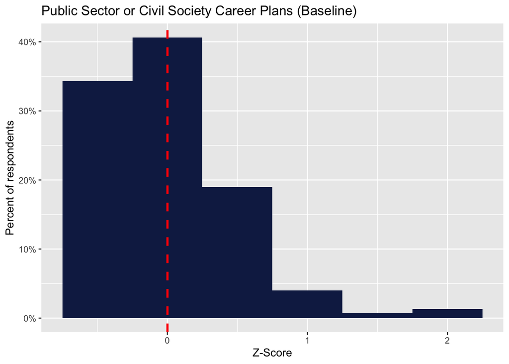

```r
# create four histograms to show endline and baseline distribution on average z scores for future plans and political question


ggplot(eth_svy , aes(x = z_future_base )) +
  geom_histogram(aes(y = after_stat(count / sum(count))),
                 binwidth= 0.5, fill = palette[9]) +
  scale_y_continuous(labels = scales::percent) +
  labs(y = "Percent of respondents", x = "Z-Score",
       title = "Public Sector or Civil Society Career Plans (Baseline)") +
  # Add a vertical line at the mean value of the data with a red dashed line
  geom_vline(xintercept = mean(eth_svy$z_future_base, na.rm = T), col = 'red', lwd = 1, linetype = 'dashed')
```

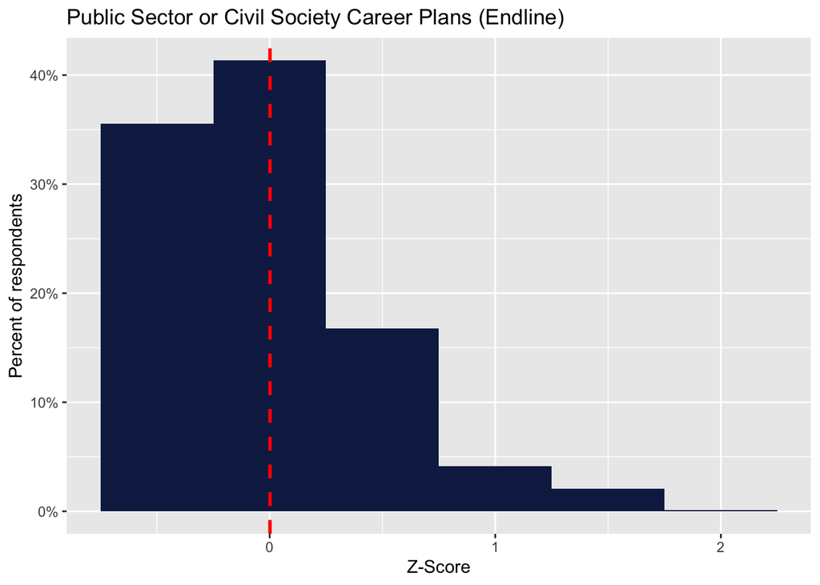

```r
ggplot(eth_svy , aes(x = z_future_end )) +
  geom_histogram(aes(y = after_stat(count / sum(count))),
                 binwidth= 0.5, fill = palette[9]) +
  scale_y_continuous(labels = scales::percent) +
  labs(y = "Percent of respondents", x = "Z-Score",
      title = "Public Sector or Civil Society Career Plans (Endline)") +
  # Add a vertical line at the mean value of the data with a red dashed line
  geom_vline(xintercept = mean(eth_svy$z_future_end, na.rm = T), col = 'red', lwd = 1, linetype = 'dashed')
```